# The importance of data analytics in the hospitality industry: 10 Reasons why it matters

Here’s a detailed breakdown of the key ways data analytics is impacting and transforming the hospitality industry:

- Personalized guest experience
- Optimized pricing
- Improved marketing efforts
- Operational efficiency
- Forecasting and strategic planning
- Enhanced food and beverage sales
- Reputation management
- Competitor analysis
- Risk management
- Sustainability initiatives

Let us understand each of them in a bit more detail:

1. **Personalized guest experience**  
   By collecting and analyzing data on guest preferences and behaviors, hospitality businesses can provide a highly personalized experience to their guests. This might include preferred room type, dietary preferences, preferred activities, and more. Such personalization not only increases guest satisfaction but also fosters loyalty.
2. **Optimized pricing**  
   Data analytics can help businesses with yield management, adjusting prices based on factors like demand, competitor pricing, local events, and historical data. This can help maximize revenue, particularly during peak periods.
3. **Improved marketing efforts**  
   Big data analytics can help identify key market segments and understand their behaviors and preferences. This allows for targeted marketing campaigns, increasing the return on marketing spend.
4. **Operational efficiency**  
   Data analytics can help identify inefficiencies in various aspects of the operation, from housekeeping to food service. By addressing these inefficiencies, businesses can improve their service while reducing costs.
5. **Forecasting and strategic planning**  
   Using historical data, businesses can forecast future demand, helping with strategic planning. This might include staffing needs, inventory management, and capital improvements.
6. **Enhanced food and beverage sales**  
   By analyzing purchasing trends and preferences, businesses can optimize their food and beverage offerings. This could lead to increased sales and reduced waste.
7. **Reputation management**  
   Online reviews and social media feedback are a gold mine of data. By analyzing this data, businesses can identify common complaints or praise and take steps to improve their service.
8. **Competitor analysis**  
   Data analytics isn’t just for analyzing your own business. It can also be used to understand competitors’ strategies and performance, helping businesses stay competitive in a crowded market.
9. **Risk management**  
   With the help of data analytics, potential risks and crises can be anticipated and mitigated. This ranges from managing overbookings to anticipating larger industry trends or potential downturns.
10. **Sustainability initiatives**  
    Data can also guide businesses in their sustainability efforts, helping them understand where they can reduce waste, conserve energy, and make other eco-friendly improvements. This not only reduces costs but also appeals to environmentally-conscious guests.

Overall, data analytics presents a multitude of opportunities for the hospitality industry to improve their service, increase efficiency, and stay competitive.

# Types of Data Analytics in the Hospitality Industry: Exploring Them in Detail

Data analytics in the hospitality industry can be categorized into several types, each serving unique purposes and providing different insights. Here are the key types of data analytics used:

1. **Descriptive analytics**: This is the most basic form of data analytics. It involves analyzing historical data to understand what has happened in the past. For instance, descriptive analytics can tell you how many guests stayed at your hotel last month, the average duration of stay, or the most popular menu item in your restaurant.
2. **Diagnostic analytics**: This type of analytics is used to understand why something happened. By analyzing detailed datasets, you can find patterns and correlations that explain past events. For example, if there was a sudden drop in your hotel bookings, diagnostic analytics might reveal that it was due to negative online reviews or a local event that impacted travel.
3. **Predictive analytics**: Predictive analytics uses statistical techniques and machine learning algorithms to analyze historical data and predict future events. In the hospitality industry, this can be used to forecast demand, allowing for optimized pricing and better resource allocation. For example, predictive analytics can tell you when the peak periods for your hotel will be, allowing you to adjust prices and staffing levels accordingly.
4. **Prescriptive analytics**: This is the most advanced form of analytics, providing recommendations on the best course of action to achieve a particular objective. It takes into account various scenarios and possibilities, leveraging optimization and simulation algorithms. In a hotel scenario, prescriptive analytics might recommend specific marketing strategies to target a new customer segment or suggest changes in room pricing to maximize revenue.
5. **Real-time analytics**: This type of analytics involves analyzing data as soon as it comes into the system, allowing businesses to respond quickly to changing situations. For instance, real-time analytics can be used in a hotel to alert staff when a room is ready for cleaning, based on data from keycard use.
6. **Sentiment analysis**: This is a form of data analytics that focuses on understanding emotions and opinions expressed in online reviews and social media posts. This can provide valuable insights into how guests perceive your hospitality business, and where improvements may be needed.

Each of these types of data analytics serves different purposes but, when used together, they provide a comprehensive view of the business, enabling better decision-making and strategy planning.

### How is Data Analytics Used in the Hospitality Industry? Discovering Newer Paradigms

Data analytics has become a key driver of success in the hospitality industry. The immense amount of data generated in this sector offers a goldmine of insights for businesses that can effectively harness it. As the industry becomes more competitive, and as customer expectations continue to evolve, the use of big data analytics and data science becomes not just a strategic advantage, but a necessity. By leveraging data analytics, businesses can uncover patterns, predict trends, optimize operations, and deliver personalized experiences that keep customers coming back.

# Use Cases of Data Analytics in the Hospitality Industry

In the hospitality industry, data analytics finds application in numerous areas, providing actionable insights and empowering businesses to make more informed decisions. Here are some of the best use cases:

1. **Personalization** In the hospitality industry, providing personalized experiences can greatly enhance customer satisfaction.
   - Data analytics helps gather detailed customer profiles, including their likes, dislikes, preferences, and behavioral patterns.
   - This can include their room preferences, dietary/travel needs, activity preferences, etc.
   - Using this data, businesses can tailor their services to individual guests, even anticipating their needs before they express them.
   - This level of personalization can lead to increased customer loyalty and higher rates of return visits.
2. **Dynamic pricing** Data analytics in the hospitality industry can help businesses with yield management, which involves adjusting prices based on a multitude of factors such as demand, competitor pricing, local events, and historical data. Historical data on occupancy rates and room prices, along with external data such as local events, weather, and market trends, can help predict periods of high and low demand. Prices can then be adjusted in real-time to maximize revenue during peak periods and encourage bookings during off-peak times.
3. **Predictive maintenance** Predictive maintenance uses data from equipment sensors, maintenance logs, and other sources to predict when equipment or infrastructure might fail. This allows for proactive maintenance, which can prevent costly downtime and unexpected issues. In a hotel, this could apply to anything from HVAC systems to kitchen appliances, potentially saving significant time and money.
4. **Demand forecasting** By analyzing historical data and considering external factors like events, seasonality, and market trends, data analytics can help predict future demand. This information is crucial for effective resource planning, including staffing levels, inventory management, and capacity planning. Research shows that hotels that leverage data analytics for demand forecasting can achieve a 5-10% improvement in revenue and a 15-20% reduction in operating costs.
5. **Customer feedback analysis** Sentiment analysis tools can be used to analyze customer reviews, social media comments, and other feedback, providing insights into how customers perceive the business. This can highlight areas for improvement, as well as areas of strength. Prompt responses to customer feedback can also enhance the business’s reputation for customer service.
6. **Competitor analysis** Data analytics in the hospitality industry isn’t limited to analyzing your own business. It can also be used to gain insights into competitors’ strategies and performance. This allows businesses to stay competitive, identify gaps in the market, and adapt to changing industry trends.
7. **Targeted marketing** With detailed customer profiles and segmentation, businesses can design more effective marketing campaigns that resonate with their target audience. This could include personalized email campaigns, targeted ads, and special offers for specific customer segments. Such targeted marketing efforts can lead to higher conversion rates and a better return on marketing spend.

These use cases demonstrate the transformative potential of data analytics in the hospitality industry. By leveraging data effectively, businesses can gain a competitive edge, improve operations, and enhance customer satisfaction. The transformative power of data analytics and data science is redefining what’s possible in hospitality, providing a roadmap for future success.

```python
import numpy as np
import pandas as pd
from datetime import datetime, timedelta

# Set random seed for reproducibility
np.random.seed(0)

# Dummy data for Personalization
num_customers = 1000
customer_ids = np.arange(1, num_customers + 1)
room_types = np.random.choice(['Standard', 'Deluxe', 'Suite'], size=num_customers)
dietary_preferences = np.random.choice(['Vegetarian', 'Vegan', 'Gluten-free', 'None'], size=num_customers)
activities_preferences = np.random.choice(['Spa', 'Golf', 'Beach', 'City Tours', 'None'], size=num_customers)

personalization_data = pd.DataFrame({
    'Customer ID': customer_ids,
    'Room Type': room_types,
    'Dietary Preference': dietary_preferences,
    'Activities Preference': activities_preferences
})

# Dummy data for Dynamic Pricing
dates = pd.date_range(start='2022-01-01', end='2022-12-31')
occupancy_rates = np.random.uniform(50, 90, size=len(dates))
room_prices = np.random.randint(100, 500, size=len(dates))

dynamic_pricing_data = pd.DataFrame({
    'Date': dates,
    'Occupancy Rate (%)': occupancy_rates,
    'Room Price ($)': room_prices
})

# Dummy data for Predictive Maintenance
equipment = ['HVAC', 'Kitchen Appliances', 'Elevator', 'Lighting']
maintenance_logs = []
for eq in equipment:
    timestamps = pd.date_range(start='2022-01-01', end='2022-12-31', freq='D')
    failures = np.random.choice([0, 1], size=len(timestamps), p=[0.95, 0.05])
    maintenance_needed = np.random.choice([0, 1], size=len(timestamps), p=[0.7, 0.3])
    maintenance_logs.extend(list(zip([eq]*len(timestamps), timestamps, failures, maintenance_needed)))

maintenance_data = pd.DataFrame(maintenance_logs, columns=['Equipment', 'Timestamp', 'Failure', 'Maintenance Needed'])

# Dummy data for Demand Forecasting
demand_dates = pd.date_range(start='2022-01-01', end='2022-12-31')
demand_trend = np.sin(np.linspace(0, 2*np.pi, len(demand_dates))) * 1000 + 500
demand_variation = np.random.normal(loc=0, scale=200, size=len(demand_dates))

demand_forecast = demand_trend + demand_variation
demand_forecast[demand_forecast < 0] = 0

demand_forecasting_data = pd.DataFrame({
    'Date': demand_dates,
    'Demand': demand_forecast
})

# Dummy data for Customer Feedback Analysis
customer_feedback = np.random.choice(['Positive', 'Neutral', 'Negative'], size=num_customers)
customer_feedback_data = pd.DataFrame({
    'Customer ID': customer_ids,
    'Feedback': customer_feedback
})

# Dummy data for Competitor Analysis
competitors = ['Competitor A', 'Competitor B', 'Competitor C']
competitor_strategies = np.random.choice(['Aggressive Pricing', 'Luxury Experience', 'Local Partnerships'], size=len(competitors))
competitor_performance = np.random.randint(1, 6, size=len(competitors))

competitor_analysis_data = pd.DataFrame({
    'Competitor': competitors,
    'Strategy': competitor_strategies,
    'Performance (1-5)': competitor_performance
})

# Dummy data for Targeted Marketing
customer_segments = np.random.choice(['Frequent Travelers', 'Family Vacationers', 'Business Travelers'], size=num_customers)
marketing_campaigns = np.random.choice(['Discount Offers', 'Exclusive Packages', 'Loyalty Programs'], size=num_customers)

targeted_marketing_data = pd.DataFrame({
    'Customer ID': customer_ids,
    'Segment': customer_segments,
    'Campaign': marketing_campaigns
})

# Output the data to CSV files
personalization_data.to_csv('personalization_data.csv', index=False)
dynamic_pricing_data.to_csv('dynamic_pricing_data.csv', index=False)
maintenance_data.to_csv('maintenance_data.csv', index=False)
demand_forecasting_data.to_csv('demand_forecasting_data.csv', index=False)
customer_feedback_data.to_csv('customer_feedback_data.csv', index=False)
competitor_analysis_data.to_csv('competitor_analysis_data.csv', index=False)
targeted_marketing_data.to_csv('targeted_marketing_data.csv', index=False)
```

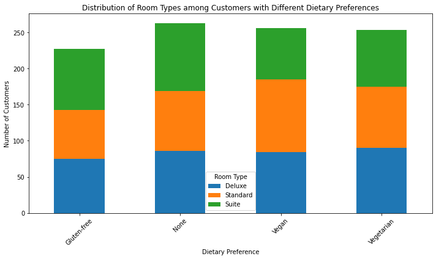

```python
import pandas as pd
import matplotlib.pyplot as plt

# Load personalization data
personalization_data = pd.read_csv('personalization_data.csv')

# Group by dietary preference and room type
grouped_data = personalization_data.groupby(['Dietary Preference', 'Room Type']).size().unstack(fill_value=0)

# Plot stacked bar chart
grouped_data.plot(kind='bar', stacked=True, figsize=(10, 6))
plt.title('Distribution of Room Types among Customers with Different Dietary Preferences')
plt.xlabel('Dietary Preference')
plt.ylabel('Number of Customers')
plt.xticks(rotation=45)
plt.legend(title='Room Type')
plt.tight_layout()
plt.show()
```

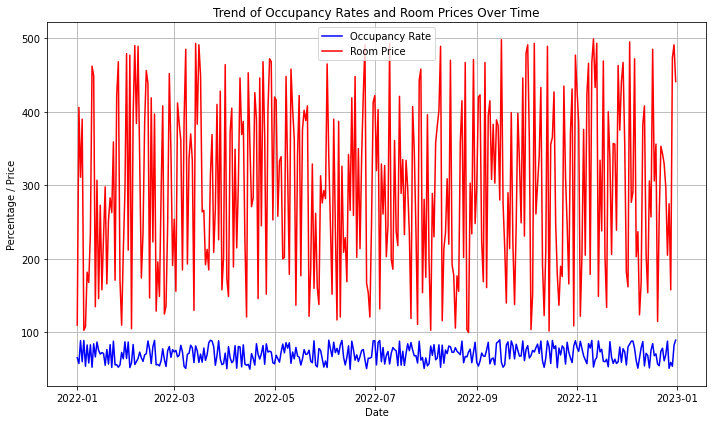

```python
import pandas as pd
import matplotlib.pyplot as plt

# Load dynamic pricing data
dynamic_pricing_data = pd.read_csv('dynamic_pricing_data.csv')

# Convert the 'Date' column to datetime
dynamic_pricing_data['Date'] = pd.to_datetime(dynamic_pricing_data['Date'])

plt.figure(figsize=(10, 6))
plt.plot(dynamic_pricing_data['Date'], dynamic_pricing_data['Occupancy Rate (%)'], color='blue', label='Occupancy Rate')
plt.plot(dynamic_pricing_data['Date'], dynamic_pricing_data['Room Price ($)'], color='red', label='Room Price')

plt.title('Trend of Occupancy Rates and Room Prices Over Time')
plt.xlabel('Date')
plt.ylabel('Percentage / Price')
plt.legend()
plt.grid(True)
plt.tight_layout()
plt.show()
```

```
Confusion Matrix:
 [[221   0]
 [ 71   0]]

Classification Report:
               precision    recall  f1-score   support

           0       0.76      1.00      0.86       221
           1       0.00      0.00      0.00        71

    accuracy                           0.76       292
   macro avg       0.38      0.50      0.43       292
weighted avg       0.57      0.76      0.65       292
```

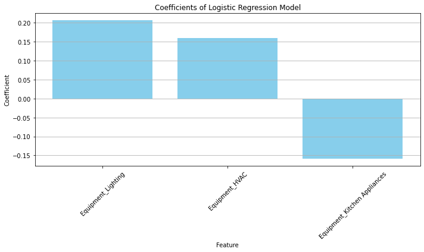

```python
import pandas as pd
import numpy as np
import matplotlib.pyplot as plt
from sklearn.linear_model import LogisticRegression
from sklearn.model_selection import train_test_split
from sklearn.metrics import confusion_matrix, classification_report

# Load maintenance data from CSV
maintenance_data = pd.read_csv('maintenance_data.csv')

# Encode categorical variable 'Equipment'
maintenance_data_encoded = pd.get_dummies(maintenance_data, columns=['Equipment'], drop_first=True)

# Define features and target variable
X = maintenance_data_encoded.drop(['Timestamp', 'Failure', 'Maintenance Needed'], axis=1)
y = maintenance_data_encoded['Maintenance Needed']

# Split data into train and test sets
X_train, X_test, y_train, y_test = train_test_split(X, y, test_size=0.2, random_state=42)

# Train logistic regression model
log_reg = LogisticRegression()
log_reg.fit(X_train, y_train)

# Predictions
y_pred = log_reg.predict(X_test)

# Confusion matrix and classification report
print("Confusion Matrix:\n", confusion_matrix(y_test, y_pred))
print("\nClassification Report:\n", classification_report(y_test, y_pred))

# Visualization of coefficients
coefficients = pd.DataFrame({'Feature': X.columns, 'Coefficient': log_reg.coef_[0]})
coefficients.sort_values(by='Coefficient', ascending=False, inplace=True)

plt.figure(figsize=(10, 6))
plt.bar(coefficients['Feature'], coefficients['Coefficient'], color='skyblue')
plt.title('Coefficients of Logistic Regression Model')
plt.xlabel('Feature')
plt.ylabel('Coefficient')
plt.xticks(rotation=45)
plt.grid(axis='y')
plt.tight_layout()
plt.show()
```

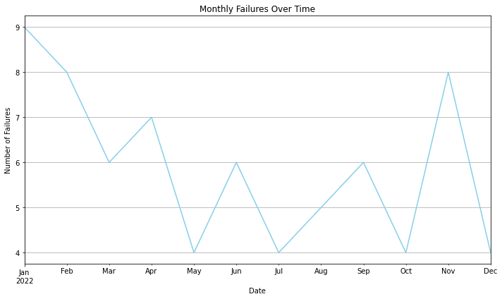

```python
import pandas as pd
import matplotlib.pyplot as plt

# Load maintenance data from CSV
maintenance_data = pd.read_csv('maintenance_data.csv')

# Convert 'Timestamp' column to datetime
maintenance_data['Timestamp'] = pd.to_datetime(maintenance_data['Timestamp'])

# Group by date and count failures
failures_by_date = maintenance_data.groupby(pd.Grouper(key='Timestamp', freq='M')).sum()['Failure']

# Plot time series of failures
plt.figure(figsize=(10, 6))
failures_by_date.plot(color='skyblue')
plt.title('Monthly Failures Over Time')
plt.xlabel('Date')
plt.ylabel('Number of Failures')
plt.grid(True)
plt.tight_layout()
plt.show()
```

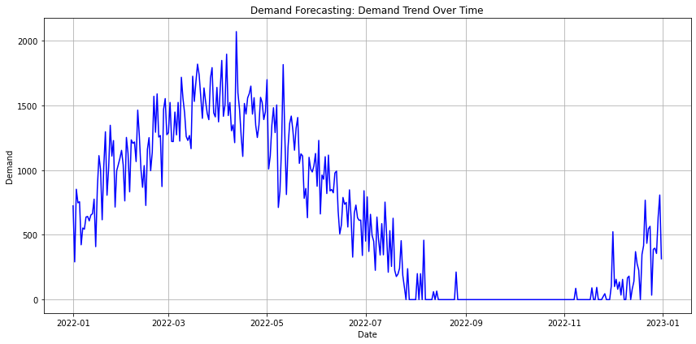

```python
# Visualizing Demand Forecasting Data
plt.figure(figsize=(12, 6))

# Plotting demand trend over time
plt.plot(demand_forecasting_data['Date'], demand_forecasting_data['Demand'], color='blue')

plt.title('Demand Forecasting: Demand Trend Over Time')
plt.xlabel('Date')
plt.ylabel('Demand')
plt.grid(True)
plt.tight_layout()
plt.show()
```

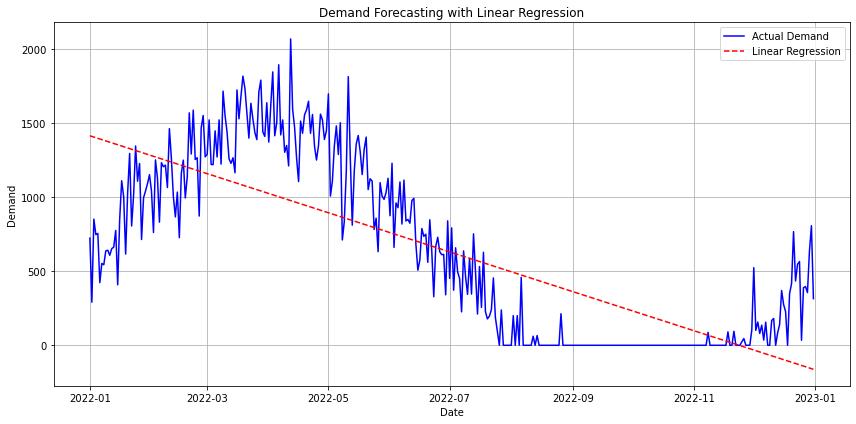

```python
from sklearn.linear_model import LinearRegression

# Convert dates to ordinal values
demand_forecasting_data['Date_Ordinal'] = demand_forecasting_data['Date'].apply(lambda x: x.toordinal())

# Extracting features (date) and target variable (demand)
X = demand_forecasting_data['Date_Ordinal'].values.reshape(-1, 1)
y = demand_forecasting_data['Demand'].values

# Creating a linear regression model
model = LinearRegression()

# Fitting the model
model.fit(X, y)

# Making predictions
predictions = model.predict(X)

# Visualizing Demand Forecasting Data with Linear Regression
plt.figure(figsize=(12, 6))

# Plotting demand trend over time
plt.plot(demand_forecasting_data['Date'], demand_forecasting_data['Demand'], color='blue', label='Actual Demand')

# Plotting linear regression line
plt.plot(demand_forecasting_data['Date'], predictions, color='red', linestyle='--', label='Linear Regression')

plt.title('Demand Forecasting with Linear Regression')
plt.xlabel('Date')
plt.ylabel('Demand')
plt.legend()
plt.grid(True)
plt.tight_layout()
plt.show()
```

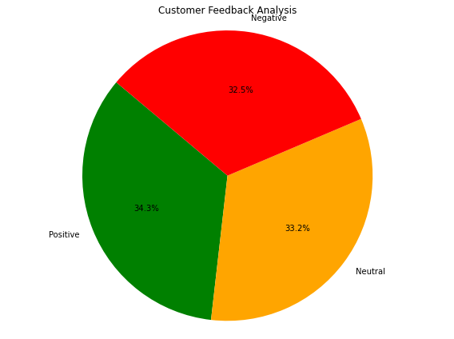

```python
# Counting the occurrences of each feedback sentiment
feedback_counts = customer_feedback_data['Feedback'].value_counts()

# Visualizing Customer Feedback Analysis
plt.figure(figsize=(8, 6))

# Creating a pie chart
plt.pie(feedback_counts, labels=feedback_counts.index, autopct='%1.1f%%', startangle=140, colors=['green', 'orange', 'red'])

plt.title('Customer Feedback Analysis')
plt.axis('equal')  # Equal aspect ratio ensures that pie is drawn as a circle.
plt.tight_layout()
plt.show()
```

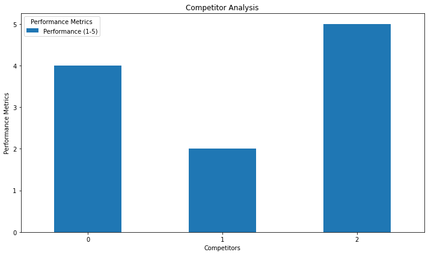

```python
# Plotting Competitor Analysis
competitor_analysis_data.plot(kind='bar', figsize=(10, 6))
plt.title('Competitor Analysis')
plt.xlabel('Competitors')
plt.ylabel('Performance Metrics')
plt.legend(title='Performance Metrics')
plt.xticks(rotation=0)  # Rotate x-axis labels for better readability
plt.tight_layout()
plt.show()
```

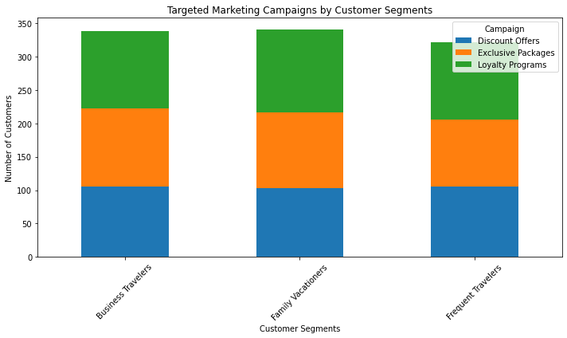

```python
# Grouping the data by segments and campaigns
segment_campaign_counts = targeted_marketing_data.groupby(['Segment', 'Campaign']).size().unstack(fill_value=0)

# Plotting the stacked bar chart
segment_campaign_counts.plot(kind='bar', stacked=True, figsize=(10, 6))
plt.title('Targeted Marketing Campaigns by Customer Segments')
plt.xlabel('Customer Segments')
plt.ylabel('Number of Customers')
plt.legend(title='Campaign')
plt.xticks(rotation=45)  # Rotate x-axis labels for better readability
plt.tight_layout()
plt.show()
```

```python
import seaborn as sns
```

```python
print("Maintenance Data Columns:", maintenance_data.columns)
print("Demand Forecasting Data Columns:", demand_forecasting_data.columns)
```

```
Maintenance Data Columns: Index(['Equipment', 'Timestamp', 'Failure', 'Maintenance Needed'], dtype='object')
Demand Forecasting Data Columns: Index(['Date', 'Demand', 'Date_Ordinal'], dtype='object')
```

```python
# Merge maintenance data and demand forecasting data on the 'Timestamp' column
combined_data = pd.merge(maintenance_data, demand_forecasting_data, left_on='Timestamp', right_on='Date', how='inner')

# Drop the redundant 'Date' column from the demand forecasting data
combined_data.drop(columns=['Date'], inplace=True)

# Convert 'Timestamp' to datetime dtype
combined_data['Timestamp'] = pd.to_datetime(combined_data['Timestamp'])

# Display the merged DataFrame
print(combined_data.head())
```

```
            Equipment  Timestamp  Failure  Maintenance Needed      Demand  \
0                HVAC 2022-01-01        0                   1  724.092830
1  Kitchen Appliances 2022-01-01        0                   1  724.092830
2            Elevator 2022-01-01        0                   0  724.092830
3            Lighting 2022-01-01        0                   0  724.092830
4                HVAC 2022-01-02        0                   0  291.285195

   Date_Ordinal
0        738156
1        738156
2        738156
3        738156
4        738157
```

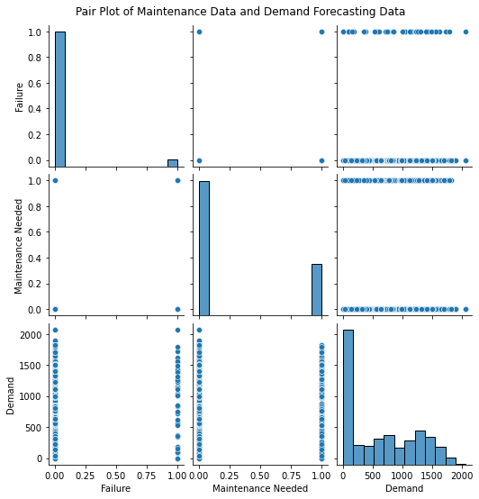

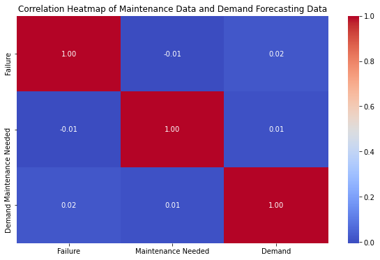

```python
# Pair plot
sns.pairplot(combined_data[['Failure', 'Maintenance Needed', 'Demand']])
plt.suptitle('Pair Plot of Maintenance Data and Demand Forecasting Data', y=1.02)
plt.show()

# Heatmap
plt.figure(figsize=(10, 6))
sns.heatmap(combined_data[['Failure', 'Maintenance Needed', 'Demand']].corr(), annot=True, cmap='coolwarm', fmt=".2f")
plt.title('Correlation Heatmap of Maintenance Data and Demand Forecasting Data')
plt.show()
```